# Prediction of Exercise Quality

Padma

12/3/2019

# Introduction

Using devices such as Jawbone Up, Nike FuelBand, and Fitbit it is now possible to collect a large amount of data about personal activity. Based on this data, people regularly try to quantify how much of a particular activity they do, but they rarely quantify how well they do it. In this assignement we try to use the data and try to predict the correctness of the activity people do.

# Read the data from pml-testing.csv and pml-training.csv

```r
setwd("D:\\Training\\Coursera\\Practical Machine Learning")
training_data_org <- read.csv("pml-training.csv")
test_data <- read.csv("pml-testing.csv")
```

# Remove columns from training that have more than 75% NA

```r
na_col <- sapply(training_data_org, function(x) mean(is.na(x))) > 0.75
training_data_org <- training_data_org[,na_col == FALSE]
test_data <- test_data[,na_col == FALSE]
```

# Remove columns A to G as they do are not relevant for this prediction

```r
training_data_org <- training_data_org[,-c(1:7)]
test_data <- test_data[,-c(1:7)]
dim(training_data_org)
```

```
## [1] 19622    86
```

# Remove columns that have near zero variance

```r
nzv_col <- nearZeroVar(training_data_org)
training_data_org <- training_data_org[, -nzv_col]
test_data  <- test_data[, -nzv_col]
dim(training_data_org)
```

```
## [1] 19622    53
```

# Split training data into training data and validation data(75% - training, 25% validation)

```r
trainingrows <- createDataPartition(training_data_org$classe, p=0.75)[[1]]
training_data <- training_data_org[trainingrows,]
validation_data <- training_data_org[-trainingrows,]
dim(training_data)
```

```
## [1] 14718    53
```

# Create model using Decision Tree. Apply the prediction on validation data and check confusion matrix

```r
modDecisionTree <- train( classe ~ .,method = "rpart", data=training_data)
print(modDecisionTree$finalModel)
```

```
## n= 14718
##
## node), split, n, loss, yval, (yprob)
##       * denotes terminal node
##
##  1) root 14718 10533 A (0.28 0.19 0.17 0.16 0.18)
##    2) roll_belt< 130.5 13487  9311 A (0.31 0.21 0.19 0.18 0.11)
##      4) pitch_forearm< -33.95 1182     8 A (0.99 0.0068 0 0 0) *
##      5) pitch_forearm>=-33.95 12305  9303 A (0.24 0.23 0.21 0.2 0.12)
##       10) magnet_dumbbell_y< 439.5 10385  7445 A (0.28 0.18 0.24 0.19 0.11)
##         20) roll_forearm< 122.5 6432  3807 A (0.41 0.18 0.18 0.17 0.062) *
##         21) roll_forearm>=122.5 3953  2648 C (0.08 0.18 0.33 0.23 0.18) *
##       11) magnet_dumbbell_y>=439.5 1920   955 B (0.032 0.5 0.045 0.23 0.19) *
##    3) roll_belt>=130.5 1231     9 E (0.0073 0 0 0 0.99) *
```

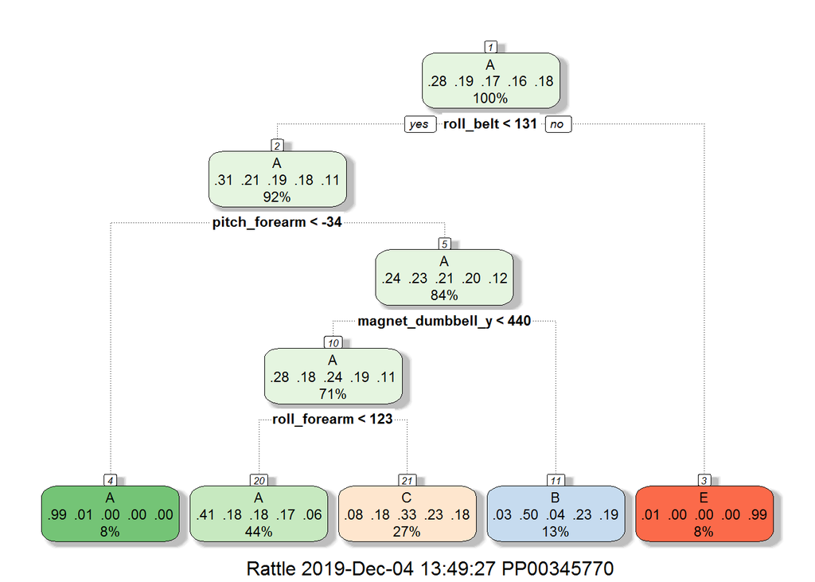

```r
fancyRpartPlot(modDecisionTree$finalModel)
```

```r
predictDecTree <- predict(modDecisionTree, validation_data)
confusionMatrix(validation_data$classe, predictDecTree)
```

```
## Confusion Matrix and Statistics
##
##           Reference
## Prediction    A    B    C    D    E
##          A 1276   19   95    0    5
##          B  395  321  233    0    0
##          C  410   22  423    0    0
##          D  367  129  308    0    0
##          E  124  118  250    0  409
##
## Overall Statistics
##
##                Accuracy : 0.4953
##                  95% CI : (0.4812, 0.5094)
##     No Information Rate : 0.5245
##     P-Value [Acc > NIR] : 1
##
##                   Kappa : 0.34
##
##  Mcnemar's Test P-Value : NA
##
## Statistics by Class:
##
##                      Class: A Class: B Class: C Class: D Class: E
## Sensitivity            0.4961  0.52709  0.32315       NA  0.98792
## Specificity            0.9490  0.85378  0.87983   0.8361  0.89042
## Pos Pred Value         0.9147  0.33825  0.49474       NA  0.45394
## Neg Pred Value         0.6307  0.92718  0.78118       NA  0.99875
## Prevalence             0.5245  0.12418  0.26692   0.0000  0.08442
## Detection Rate         0.2602  0.06546  0.08626   0.0000  0.08340
## Detection Prevalence   0.2845  0.19352  0.17435   0.1639  0.18373
## Balanced Accuracy      0.7225  0.69044  0.60149       NA  0.93917
```

# Create model using Random Forest. Apply the prediction on validation data and check confusion matrix

```r
cluster <- makeCluster(detectCores() - 1) # convention to leave 1 core for OS
registerDoParallel(cluster)
fitControl <- trainControl(method = "cv",number = 5,allowParallel = TRUE)
modRandomForest <- train( classe ~ .,method = "rf", data=training_data, trControl = fitControl)
print(modRandomForest$finalModel)
```

```
##
## Call:
##  randomForest(x = x, y = y, mtry = param$mtry)
##                Type of random forest: classification
##                      Number of trees: 500
## No. of variables tried at each split: 27
##
##         OOB estimate of  error rate: 0.65%
## Confusion matrix:
##      A    B    C    D    E class.error
## A 4176    8    1    0    0 0.002150538
## B   19 2823    6    0    0 0.008778090
## C    0   14 2541   12    0 0.010128555
## D    0    1   21 2388    2 0.009950249
## E    0    3    3    5 2695 0.004065041
```

```r
predictRandForest <- predict(modRandomForest, validation_data)
confusionMatrix(validation_data$classe, predictRandForest)
```

```
## Confusion Matrix and Statistics
##
##           Reference
## Prediction    A    B    C    D    E
##          A 1392    1    1    0    1
##          B    3  944    2    0    0
##          C    0    0  855    0    0
##          D    0    1   14  787    2
##          E    0    0    1    7  893
##
## Overall Statistics
##
##                Accuracy : 0.9933
##                  95% CI : (0.9906, 0.9954)
##     No Information Rate : 0.2845
##     P-Value [Acc > NIR] : < 2.2e-16
##
##                   Kappa : 0.9915
##
##  Mcnemar's Test P-Value : NA
##
## Statistics by Class:
##
##                      Class: A Class: B Class: C Class: D Class: E
## Sensitivity            0.9978   0.9979   0.9794   0.9912   0.9967
## Specificity            0.9991   0.9987   1.0000   0.9959   0.9980
## Pos Pred Value         0.9978   0.9947   1.0000   0.9789   0.9911
## Neg Pred Value         0.9991   0.9995   0.9956   0.9983   0.9993
## Prevalence             0.2845   0.1929   0.1780   0.1619   0.1827
## Detection Rate         0.2838   0.1925   0.1743   0.1605   0.1821
## Detection Prevalence   0.2845   0.1935   0.1743   0.1639   0.1837
## Balanced Accuracy      0.9985   0.9983   0.9897   0.9935   0.9973
```

```r
stopCluster(cluster)
```

# Accuracy of RandomForest model is more than 99% which is way above the accuracy of Decision Tree model. Hence we chose RandomForest model to predict classe of the test set.

```r
predict(modRandomForest, test_data)
```

```
##  [1] B A B A A E D B A A B C B A E E A B B B
## Levels: A B C D E
```